# Neg-tablet Analyses

AEN and MCF

Prelims and libraries.

```r
rm(list = ls())
#Load libraries
library(reshape2)
library(dplyr)
```

```r
library(ggplot2)
library(bootstrap)
library(lme4)
```

Functions and add some style elements for ggplot2

```r
## number of unique subs
n.unique <- function (x) {
  length(unique(x))
}

## for bootstrapping 95% confidence intervals
theta <- function(x,xdata) {mean(xdata[x])}
ci.low <- function(x) {
  quantile(bootstrap(1:length(x), 1000, theta, x)$thetastar, .025)}
ci.high <- function(x) {
  quantile(bootstrap(1:length(x), 1000, theta, x)$thetastar, .975)}

plot.style <- theme_bw() +
  theme(panel.grid.minor = element_blank(),
        panel.grid.major = element_blank(),
        legend.position = "right",
        axis.line = element_line(colour = "black",size = .5),
        axis.ticks = element_line(size = .5),
        axis.title.x = element_text(vjust = -.5),
        axis.title.y = element_text(angle = 90,vjust = 0.25))
```

## Experiment 1: Adults, between-subjects, referent type & syntactic frame

Load in data

```r
d.exp1 <- read.csv("data/exp1.csv")
d.exp1$condition <- factor(d.exp1$condition,
                           levels = c("noContext", "context"),
                           labels = c("None", "Target"))
d.exp1$sentence.type <- factor(d.exp1$sentence.type,
                               levels = c("positive", "negative"),
                               labels = c("Positive" , "Negative"))

d.exp1$neg.concept <- factor(d.exp1$neg.concept,
                             levels = c("something", "nothing"),
                             labels = c("Alternative",  "Nonexistence"))

d.exp1$neg.syntax <- factor(d.exp1$neg.syntax,
                            levels = c("", "has no", "doesn't have"),
                            labels = c("", "has no X", "doesn't have X"))
```

### Plot data

Histogram of rating scale:

```
## stat_bin: binwidth defaulted to range/30. Use 'binwidth = x' to adjust this.
```

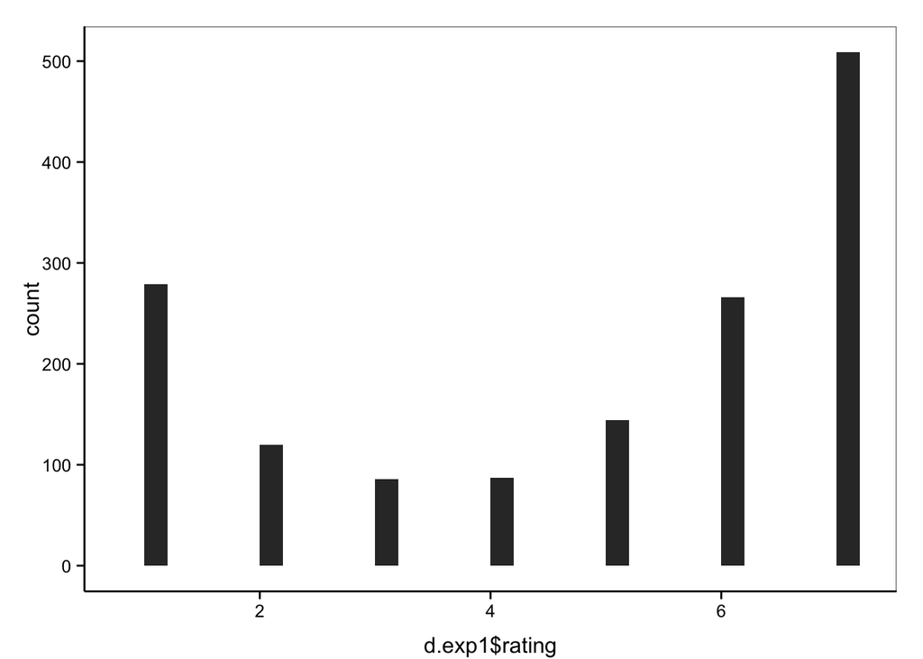

```r
qplot(d.exp1$rating, geom = "histogram") + plot.style
```

Plot mean ratings for every trial type:

```
## ymax not defined: adjusting position using y instead
## ymax not defined: adjusting position using y instead
## ymax not defined: adjusting position using y instead
## ymax not defined: adjusting position using y instead
```

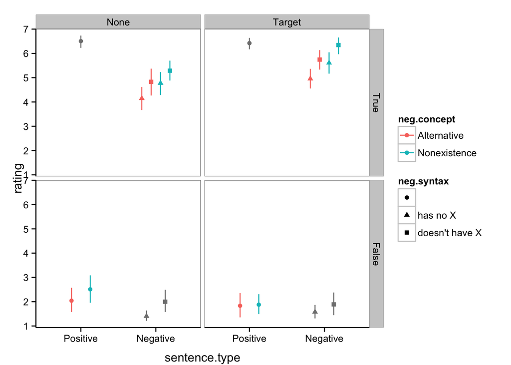

```r
ms <- d.exp1 %>%
  group_by(subid, condition, sentence.type, truth.value, neg.concept, neg.syntax) %>%
  summarise(subm = mean(rating)) %>%
  group_by(condition, sentence.type, truth.value, neg.concept, neg.syntax) %>%
  summarise(rating = mean(subm),
            high = ci.high(subm),
            low = ci.low(subm))
ms$truth.value <- factor(ms$truth.value, levels=c(TRUE, FALSE), labels=c("True","False"))

qplot(data = ms, x = sentence.type, y = rating,
      color = neg.concept, shape = neg.syntax,
      geom = "point", stat = "identity", position = position_dodge(width = .5),
      facets = ~ truth.value~condition) +
  geom_errorbar(aes(ymin = low, ymax = high), width = 0,
                position = position_dodge(width = .5)) +
  plot.style
```

Just look at negative sentences:

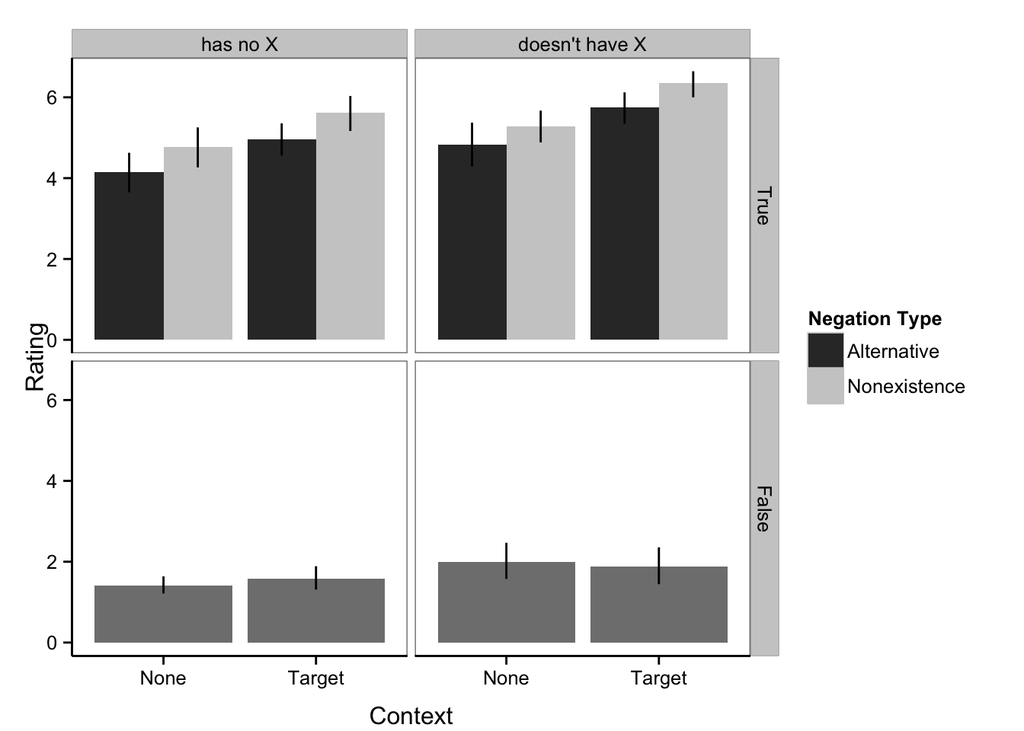

```r
d.exp1.neg <- filter(d.exp1, sentence.type == "Negative")

ms <- d.exp1.neg %>%
  group_by(subid, condition, truth.value, neg.concept, neg.syntax) %>%
  summarise(subm = mean(rating)) %>%
  group_by(condition, truth.value, neg.concept, neg.syntax) %>%
  summarise(rating = mean(subm),
            high = ci.high(subm),
            low = ci.low(subm))
ms$truth.value <- factor(ms$truth.value, levels=c(TRUE, FALSE), labels=c("True","False"))

qplot(data = ms, x = condition, y = rating, fill = neg.concept,
      geom = "bar", stat = "identity", position = "dodge",
      facets = truth.value~neg.syntax) +
  geom_errorbar(aes(ymin = low, ymax = high), width = 0,
                position = position_dodge(width = .9)) +
  scale_fill_grey("Negation Type") +
  xlab("Context") + ylab("Rating") +
  plot.style
```

Just look at true negatives:

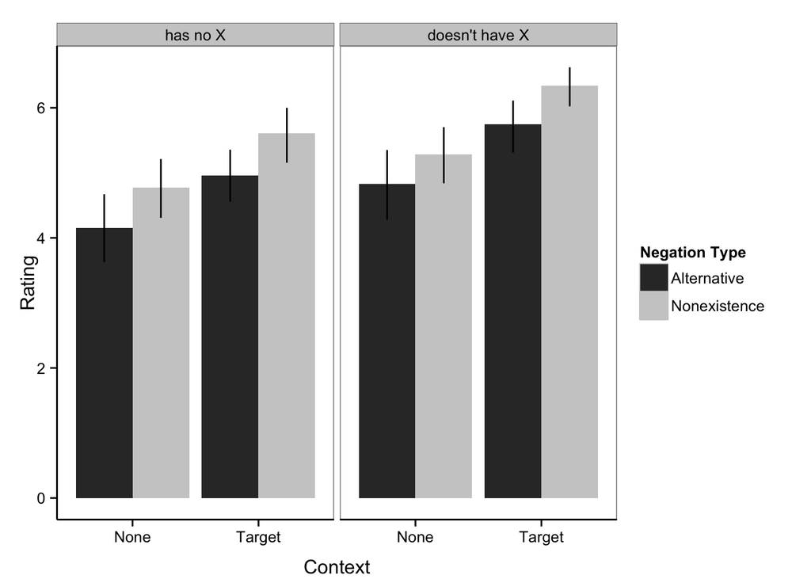

```r
d.exp1.trueneg <- filter(d.exp1, sentence.type ==  "Negative" & truth.value == TRUE)

ms <- d.exp1.trueneg %>%
  group_by(subid, condition, neg.concept, neg.syntax) %>%
  summarise(subm = mean(rating)) %>%
  group_by(condition, neg.concept, neg.syntax) %>%
  summarise(rating = mean(subm),
            high = ci.high(subm),
            low = ci.low(subm))

qplot(data = ms, x = condition, y = rating, fill = neg.concept,
      geom = "bar", stat = "identity", position = "dodge",
      facets = ~neg.syntax) +
  geom_errorbar(aes(ymin = low, ymax = high), width = 0,
                position = position_dodge(width = .9)) +
  scale_fill_grey("Negation Type") +
  xlab("Context") + ylab("Rating") +
  plot.style
```

### Statistical models:

All data:

```r
model.exp1.all <- lmer(rating ~ sentence.type * condition * truth.value +
                         (sentence.type * truth.value | subid) +
                         (sentence.type * truth.value | item),
                       data = d.exp1)
summary(model.exp1.all)
```

```
## Linear mixed model fit by REML ['lmerMod']
## Formula:
## rating ~ sentence.type * condition * truth.value + (sentence.type *
##     truth.value | subid) + (sentence.type * truth.value | item)
##    Data: d.exp1
##
## REML criterion at convergence: 5090.5
##
## Scaled residuals:
##     Min      1Q  Median      3Q     Max
## -4.7040 -0.3299  0.0629  0.4537  3.5049
##
## Random effects:
##  Groups   Name                                  Variance Std.Dev. Corr
##  subid    (Intercept)                           1.89092  1.3751
##           sentence.typeNegative                 0.39742  0.6304   -0.87
##           truth.valueTRUE                       2.53910  1.5935   -0.93
##           sentence.typeNegative:truth.valueTRUE 1.78861  1.3374    0.41
##  item     (Intercept)                           0.02824  0.1681
##           sentence.typeNegative                 0.01701  0.1304   -0.93
##           truth.valueTRUE                       0.03912  0.1978   -0.92
##           sentence.typeNegative:truth.valueTRUE 0.07259  0.2694    0.88
##  Residual                                       1.34280  1.1588
##
##
##
##   0.70
##  -0.78 -0.29
##
##
##   0.72
##  -0.99 -0.62
##
## Number of obs: 1491, groups:  subid, 92; item, 16
##
## Fixed effects:
##                                                       Estimate Std. Error
## (Intercept)                                             2.2728     0.2375
## sentence.typeNegative                                  -0.5732     0.1955
## conditionTarget                                        -0.3947     0.3338
```

[output cut: 9 more lines]

```
## truth.valueTRUE                                        15.155
## sentence.typeNegative:conditionTarget                   1.552
## sentence.typeNegative:truth.valueTRUE                  -4.095
## conditionTarget:truth.valueTRUE                         0.780
## sentence.typeNegative:conditionTarget:truth.valueTRUE   1.428
##
## Correlation of Fixed Effects:
##             (Intr) sntn.N cndtnT t.TRUE sn.N:T s.N:.T cT:.TR
## sntnc.typNg -0.682
## conditnTrgt -0.689  0.466
## trth.vlTRUE -0.901  0.560  0.620
## sntnc.tyN:T  0.466 -0.692 -0.675 -0.384
## snt.N:.TRUE  0.483 -0.801 -0.318 -0.461  0.543
## cndtT:.TRUE  0.620 -0.383 -0.900 -0.689  0.555  0.310
## s.N:T:.TRUE -0.322  0.550  0.466  0.314 -0.795 -0.681 -0.454
```

Just negative sentences:

```r
model.exp1.neg <- lmer(rating ~ condition * truth.value +
                         (truth.value | subid) +
                         (condition * truth.value | item),
                       data = d.exp1.neg)
summary(model.exp1.neg)
```

```
## Linear mixed model fit by REML ['lmerMod']
## Formula:
## rating ~ condition * truth.value + (truth.value | subid) + (condition *
##     truth.value | item)
##    Data: d.exp1.neg
##
## REML criterion at convergence: 3326.8
##
## Scaled residuals:
##     Min      1Q  Median      3Q     Max
## -4.0309 -0.4323  0.0400  0.5371  3.3000
##
## Random effects:
##  Groups   Name                            Variance Std.Dev. Corr
##  subid    (Intercept)                     0.52070  0.7216
##           truth.valueTRUE                 2.78651  1.6693   -0.81
##  item     (Intercept)                     0.01807  0.1344
##           conditionTarget                 0.10886  0.3299   -0.75
##           truth.valueTRUE                 0.01549  0.1245    0.19 -0.79
##           conditionTarget:truth.valueTRUE 0.08202  0.2864    0.99 -0.65
##  Residual                                 1.61149  1.2694
##
##
##
##
##
##
##   0.06
##
## Number of obs: 930, groups:  subid, 92; item, 16
##
## Fixed effects:
##                                 Estimate Std. Error t value
## (Intercept)                      1.70258    0.17150   9.928
## conditionTarget                  0.03042    0.25472   0.119
## truth.valueTRUE                  3.06173    0.28598  10.706
## conditionTarget:truth.valueTRUE  0.86353    0.41302   2.091
##
## Correlation of Fixed Effects:
##             (Intr) cndtnT t.TRUE
## conditnTrgt -0.695
## trth.vlTRUE -0.773  0.495
## cndtT:.TRUE  0.572 -0.779 -0.683
```

Just true negative sentences:

```r
model.exp1.trueneg <- lmer(rating ~ condition * neg.concept * neg.syntax +
                             (neg.concept * neg.syntax | subid) +
                             (neg.concept * neg.syntax | item),
                           data = d.exp1.trueneg)
summary(model.exp1.trueneg)
```

```
## Linear mixed model fit by REML ['lmerMod']
## Formula: rating ~ condition * neg.concept * neg.syntax + (neg.concept *
##     neg.syntax | subid) + (neg.concept * neg.syntax | item)
##    Data: d.exp1.trueneg
##
## REML criterion at convergence: 2524.4
##
## Scaled residuals:
##     Min      1Q  Median      3Q     Max
## -4.1048 -0.3598  0.0778  0.4357  2.6292
##
## Random effects:
##  Groups   Name                                             Variance
##  subid    (Intercept)                                      2.07631
##           neg.conceptNonexistence                          0.63752
##           neg.syntaxdoesn't have X                         1.52544
##           neg.conceptNonexistence:neg.syntaxdoesn't have X 0.39854
##  item     (Intercept)                                      0.05413
##           neg.conceptNonexistence                          0.13166
##           neg.syntaxdoesn't have X                         0.15699
##           neg.conceptNonexistence:neg.syntaxdoesn't have X 0.08101
##  Residual                                                  0.95882
##  Std.Dev. Corr
##  1.4409
##  0.7984   -0.29
##  1.2351   -0.34 -0.15
##  0.6313   -0.15 -0.78 -0.16
##  0.2327
##  0.3628   -0.61
##  0.3962   -0.61 -0.05
##  0.2846    0.98 -0.72 -0.58
##  0.9792
## Number of obs: 744, groups:  subid, 92; item, 16
##
## Fixed effects:
##                                                                   Estimate
## (Intercept)                                                       4.132994
## conditionTarget                                                   0.822253
## neg.conceptNonexistence                                           0.653713
## neg.syntaxdoesn't have X                                          0.708262
```

[output cut: 17 more lines]

```
## neg.syntaxdoesn't have X                                           2.813
## conditionTarget:neg.conceptNonexistence                           -0.011
## conditionTarget:neg.syntaxdoesn't have X                           0.140
## neg.conceptNonexistence:neg.syntaxdoesn't have X                  -0.930
## conditionTarget:neg.conceptNonexistence:neg.syntaxdoesn't have X   0.674
##
## Correlation of Fixed Effects:
##             (Intr) cndtnT ng.cnN ng.'hX cnT:.N cT:.'hX n.N:hX
## conditnTrgt -0.680
## ng.cncptNnx -0.419  0.257
## ng.syntx'hX -0.442  0.277  0.135
## cndtnTrg:.N  0.278 -0.406 -0.631 -0.114
## cndtnT:.'hX  0.293 -0.429 -0.111 -0.644  0.172
## ng.cnN:.'hX  0.204 -0.097 -0.699 -0.470  0.472  0.306
## cnT:.N:.'hX -0.099  0.143  0.446  0.298 -0.705 -0.456  -0.671
```

## Experiment 2: Adults, within-subjects, foil context

Load in data

```r
d.exp2 <- read.csv("data/exp2.csv")
d.exp2$sentence.type <- factor(d.exp2$sentence.type,
                               levels = c("positive", "negative"),
                               labels = c("Positive", "Negative"))
d.exp2$condition <- factor(d.exp2$condition,
                           levels = c("none", "foil", "target"),
                           labels = c("None", "Foil", "Target"))
```

### Plot data

Histogram of rating scale:

```
## stat_bin: binwidth defaulted to range/30. Use 'binwidth = x' to adjust this.
```

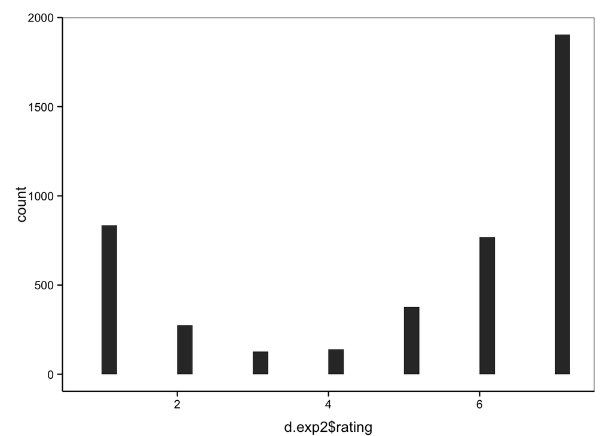

```r
qplot(d.exp2$rating, geom = "histogram") + plot.style
```

Plot mean ratings for every trial type:

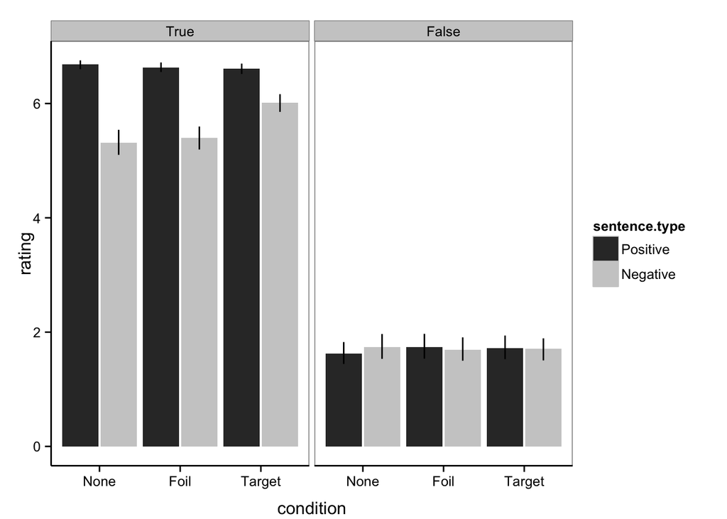

```r
ms <- d.exp2 %>%
  group_by(subid, condition, sentence.type, truth.value) %>%
  summarise(subm = mean(rating)) %>%
  group_by(condition, sentence.type, truth.value) %>%
  summarise(rating = mean(subm),
            high = ci.high(subm),
            low = ci.low(subm))
ms$truth.value <- factor(ms$truth.value, levels=c(TRUE, FALSE), labels=c("True","False"))

qplot(data = ms, x = condition, y = rating, fill = sentence.type,
      geom = "bar", stat = "identity", position = position_dodge(width = .95),
      facets = ~truth.value) +
  geom_errorbar(aes(ymin = low, ymax = high), width = 0,
                position = position_dodge(width = .95)) +
  scale_fill_grey() +
  plot.style
```

Just look at true negatives:

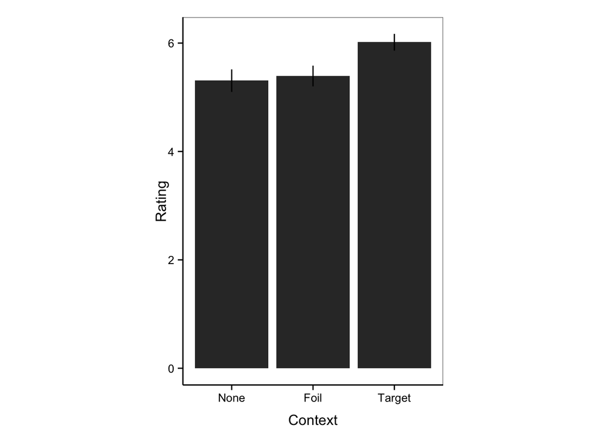

```r
d.exp2.trueneg <- filter(d.exp2, sentence.type ==  "Negative" & truth.value ==  TRUE)

ms <- d.exp2.trueneg %>%
  group_by(subid, condition) %>%
  summarise(subm = mean(rating)) %>%
  group_by(condition) %>%
  summarise(rating = mean(subm),
            high = ci.high(subm),
            low = ci.low(subm))

qplot(data = ms, x = condition, y = rating,
      geom = "bar", stat = "identity", position = "dodge") +
  geom_errorbar(aes(ymin = low, ymax = high), width = 0,
                position = position_dodge(width = .9)) +
  scale_fill_grey() +
  xlab("Context") + ylab("Rating") +
  coord_equal(1/1.5) +
  plot.style
```

### Statistical models:

All data:

```r
model.exp2.all <- lmer(rating ~ condition * sentence.type * truth.value +
                         (sentence.type * truth.value | subid) +
                         (sentence.type * truth.value | item),
                       data = d.exp2)
summary(model.exp2.all)
```

```
## Linear mixed model fit by REML ['lmerMod']
## Formula:
## rating ~ condition * sentence.type * truth.value + (sentence.type *
##     truth.value | subid) + (sentence.type * truth.value | item)
##    Data: d.exp2
##
## REML criterion at convergence: 13252.2
##
## Scaled residuals:
##     Min      1Q  Median      3Q     Max
## -5.9597 -0.2584  0.0534  0.3443  5.0692
##
## Random effects:
##  Groups   Name                                  Variance Std.Dev. Corr
##  subid    (Intercept)                           1.229589 1.10887
##           sentence.typeNegative                 0.157841 0.39729  -0.20
##           truth.valueTRUE                       1.791112 1.33832  -0.96
##           sentence.typeNegative:truth.valueTRUE 1.154283 1.07438   0.20
##  item     (Intercept)                           0.005273 0.07262
##           sentence.typeNegative                 0.015855 0.12592  -0.92
##           truth.valueTRUE                       0.004598 0.06781  -0.99
##           sentence.typeNegative:truth.valueTRUE 0.014442 0.12018   0.39
##  Residual                                       0.915086 0.95660
##
##
##
##   0.24
##  -0.42 -0.14
##
##
##   0.87
##  -0.72 -0.29
##
## Number of obs: 4426, groups:  subid, 184; item, 24
##
## Fixed effects:
##                                                       Estimate Std. Error
## (Intercept)                                            1.62759    0.10901
## conditionFoil                                          0.11813    0.09958
## conditionTarget                                        0.10630    0.09956
```

[output cut: 33 more lines]

```
## snt.N:.TRUE  0.413 -0.352 -0.352 -0.748 -0.429  0.496  0.496  0.407  0.407
## cF:.N:.TRUE -0.280  0.612  0.307  0.570  0.316 -0.865 -0.433 -0.707 -0.354
## cT:.N:.TRUE -0.280  0.307  0.611  0.570  0.316 -0.433 -0.866 -0.354 -0.706
##             s.N:.T cF:.N:
## conditionFl
## conditnTrgt
## sntnc.typNg
## trth.vlTRUE
## cndtnFl:s.N
## cndtnTrg:.N
## cndtF:.TRUE
## cndtT:.TRUE
## snt.N:.TRUE
## cF:.N:.TRUE -0.573
## cT:.N:.TRUE -0.573  0.500
```

Just negative sentences:

```r
model.exp2.neg <- lmer(rating ~ condition * truth.value +
                         (truth.value | subid) +
                         (truth.value | item),
                       data = filter(d.exp2, sentence.type == "Negative"))
summary(model.exp2.neg)
```

```
## Linear mixed model fit by REML ['lmerMod']
## Formula:
## rating ~ condition * truth.value + (truth.value | subid) + (truth.value |
##     item)
##    Data: filter(d.exp2, sentence.type == "Negative")
##
## REML criterion at convergence: 7520.8
##
## Scaled residuals:
##     Min      1Q  Median      3Q     Max
## -4.9794 -0.2616 -0.0199  0.3974  3.8521
##
## Random effects:
##  Groups   Name            Variance  Std.Dev.  Corr
##  subid    (Intercept)     1.089e+00 1.0437151
##           truth.valueTRUE 2.378e+00 1.5422250 -0.70
##  item     (Intercept)     7.521e-08 0.0002742
##           truth.valueTRUE 2.794e-03 0.0528618 -0.99
##  Residual                 1.303e+00 1.1414781
## Number of obs: 2212, groups:  subid, 184; item, 24
##
## Fixed effects:
##                                 Estimate Std. Error t value
## (Intercept)                      1.74538    0.11375  15.344
## conditionFoil                   -0.05517    0.11875  -0.465
## conditionTarget                 -0.03886    0.11875  -0.327
## truth.valueTRUE                  3.56625    0.14974  23.816
## conditionFoil:truth.valueTRUE    0.14050    0.13722   1.024
## conditionTarget:truth.valueTRUE  0.74014    0.13720   5.395
##
## Correlation of Fixed Effects:
##             (Intr) cndtnF cndtnT t.TRUE cF:.TR
## conditionFl -0.520
## conditnTrgt -0.520  0.498
## trth.vlTRUE -0.772  0.395  0.395
## cndtF:.TRUE  0.450 -0.865 -0.431 -0.456
## cndtT:.TRUE  0.450 -0.431 -0.866 -0.457  0.498
```

Just true negative sentences:

```r
model.exp2.trueneg <- lmer(rating ~ condition +
                             (1 | subid) +
                             (1 | item),
                           data = d.exp2.trueneg)
summary(model.exp2.trueneg)
```

```
## Linear mixed model fit by REML ['lmerMod']
## Formula: rating ~ condition + (1 | subid) + (1 | item)
##    Data: d.exp2.trueneg
##
## REML criterion at convergence: 5624.1
##
## Scaled residuals:
##     Min      1Q  Median      3Q     Max
## -4.8819 -0.3289  0.1748  0.4520  2.8403
##
## Random effects:
##  Groups   Name        Variance Std.Dev.
##  subid    (Intercept) 1.203608 1.097
##  item     (Intercept) 0.002025 0.045
##  Residual             1.356407 1.165
## Number of obs: 1658, groups:  subid, 184; item, 24
##
## Fixed effects:
##                 Estimate Std. Error t value
## (Intercept)      5.31157    0.09530   55.73
## conditionFoil    0.08502    0.07013    1.21
## conditionTarget  0.70177    0.07009   10.01
##
## Correlation of Fixed Effects:
##             (Intr) cndtnF
## conditionFl -0.367
## conditnTrgt -0.368  0.499
```

## Model comparison

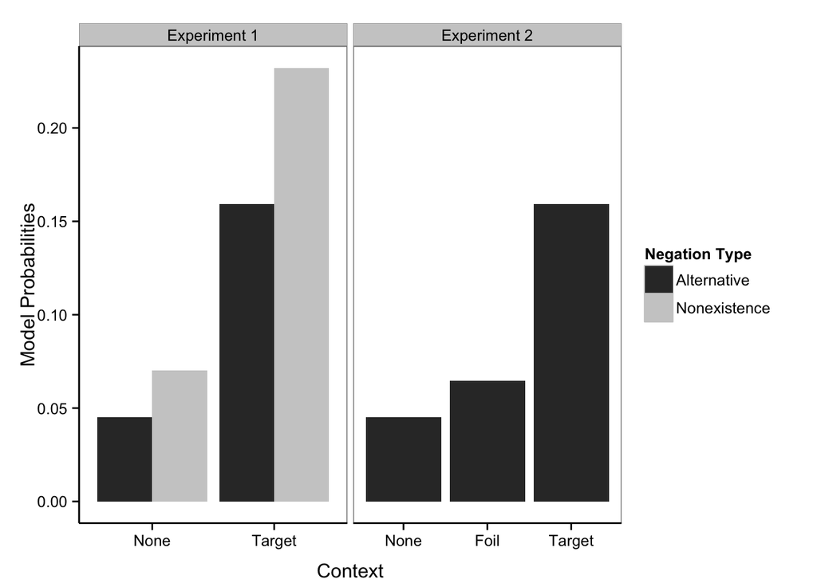

```r
source("model/model.R")
source("model/simulations.R")

qplot(data=subset(probs, truth.value=="True" & word=="negative"),
      x=context, y=p.word, fill=negation.type,
      geom="bar", stat="identity", position="dodge") +
  facet_grid(.~experiment, scales="free") +
  #ggtitle("Model predictions") +
  scale_fill_grey("Negation Type") +
  xlab("Context") + ylab("Model Probabilities") +
  plot.style
```

## Experiment 3: Children, between subjects, none vs. target context

Load in data.

```r
d.exp3 <- read.csv("data/exp3.csv")

d.exp3$agegroup <- factor(d.exp3$agegroup)

d.exp3$sent.type <- factor(d.exp3$sent.type,
                           levels = c("positive", "negative"),
                           labels = c("Positive", "Negative"))

d.exp3$condition <- factor(d.exp3$condition,
                           labels = c("None", "Target"))
```

Condense scale from 5-point to 3-point

```r
d.exp3$resp2 <- 2
d.exp3[d.exp3$resp > 3,]$resp2 <- 3
d.exp3[d.exp3$resp < 3,]$resp2 <- 1
d.exp3$resp2 <- factor(d.exp3$resp2)
```

### Participant exclusions

Exclude subjects who didn’t complete at least half of the trials

```r
#Reject children who didn't complete at least 8 trials
ntrials <- d.exp3 %>%
  group_by(subid) %>%
  summarize(ntrials = n()) %>%
  filter(ntrials < 8)

for (i in ntrials$subid) {
  d.exp3 <- filter(d.exp3, subid != i)
}
```

Reject subjects who don’t understand scale (based on positive sentences):

```r
reject <- d.exp3 %>%
  filter(sent.type == "Positive") %>% #Only look at positive sentences
  group_by(subid) %>%
  mutate(total = n()) %>% #get total # of positive sentences child saw
  group_by(subid, condition, truth, total, resp2) %>%
  filter((truth == "True" & resp2 == 3) | (truth == "False" & resp2 == 1)) %>% #Get # "good" for true pos and "bad" for false pos
  summarize(counts = n()) %>%
  group_by(subid, condition, total) %>%
  summarize(counts = sum(counts)) %>% #total # "correct" responses
  mutate(prop = counts/total) %>% #proportion correct
  filter(prop < .6) #reject kids who got < .6 "correct" (this allows for 2/6 "mistakes")

for (i in reject$subid) {
  d.exp3 <- filter(d.exp3, subid != i)
}
```

Make sure there aren’t any kids who just used one side of scale. Reject kids who only chose a single data point

```r
scaleUse <- aggregate(resp2 ~ subid, d.exp3, n.unique)
table(scaleUse$resp2) #Are any resp2 = 1
```

```
##
##  2  3
## 48 21
```

### Plot data, all ages

Categorize kids based on response type

```r
tn_responses <- d.exp3 %>%
  filter(sent.type == "Negative" & truth == "True") %>%
  group_by(subid) %>%
  mutate(total = n()) %>%
  group_by(subid, condition, total, resp2) %>%
  summarize(counts = n()) %>%
  mutate(prop = counts/total)

category <- dcast(tn_responses, subid + condition ~ resp2)
```

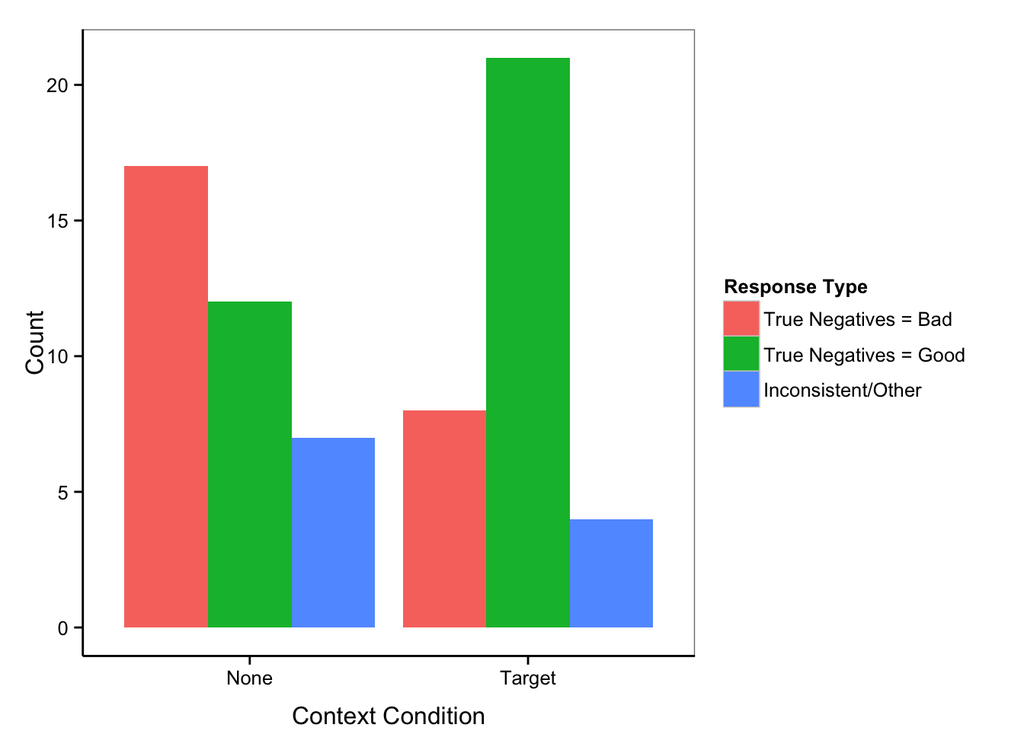

```r
names(category) <- c("subid","condition","bad","neutral","good")
category[is.na(category)] <- 0

category$type <- "other"
#category[category$neutral > .6,]$type <- "tn_neutral"
category[category$bad > .6,]$type <- "tn_bad"
category[category$good > .6,]$type <- "tn_good"

cat_counts <- category %>%
  group_by(condition, type) %>%
  summarise(counts = n())

cat_counts$type <- factor(cat_counts$type, levels = c("tn_bad","tn_good","other"), labels = c("True Negatives = Bad", "True Negatives = Good", "Inconsistent/Other"))

qplot(data = cat_counts, x = condition, y = counts, fill = type,
      stat = "identity", position = "dodge", geom = "bar") +
  scale_fill_hue("Response Type") +
  ylab("Count") + xlab("Context Condition") +
  plot.style
```

Mean responses to all sentences:

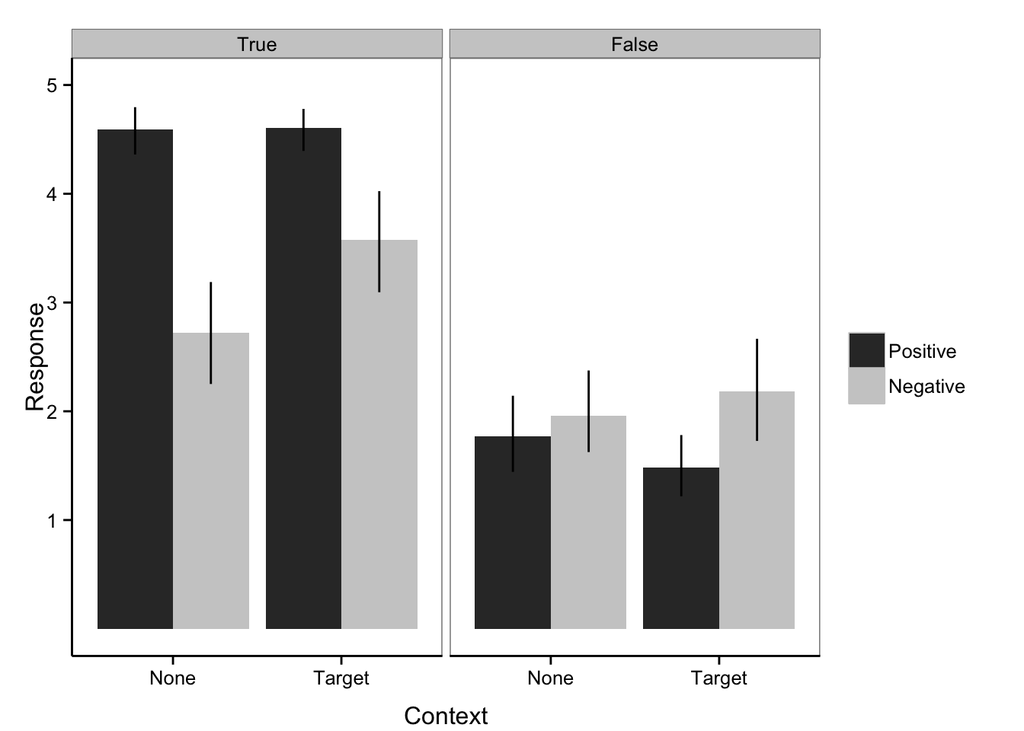

```r
ms <- d.exp3 %>%
  group_by(subid, condition, sent.type, truth) %>%
  summarise(subm = mean(resp)) %>%
  group_by(condition, sent.type, truth) %>%
  summarise(m = mean(subm),
            cih = ci.high(subm),
            cil = ci.low(subm))
ms$truth <- factor(ms$truth, levels=c("True","False"))

qplot(data = subset(ms),
      x = condition, y = m, fill =  sent.type, facets = ~ truth,
      stat = "identity", position = "dodge", geom = "bar") +
  geom_errorbar(aes(ymin = cil, ymax = cih),
                position = position_dodge(.9), width = 0) +
  scale_fill_grey("") +
  xlab("Context") + ylab("Response") +
  scale_y_continuous(limits = c(0, 5), breaks = seq(1,5,1)) +
  plot.style
```

Just negative trials:

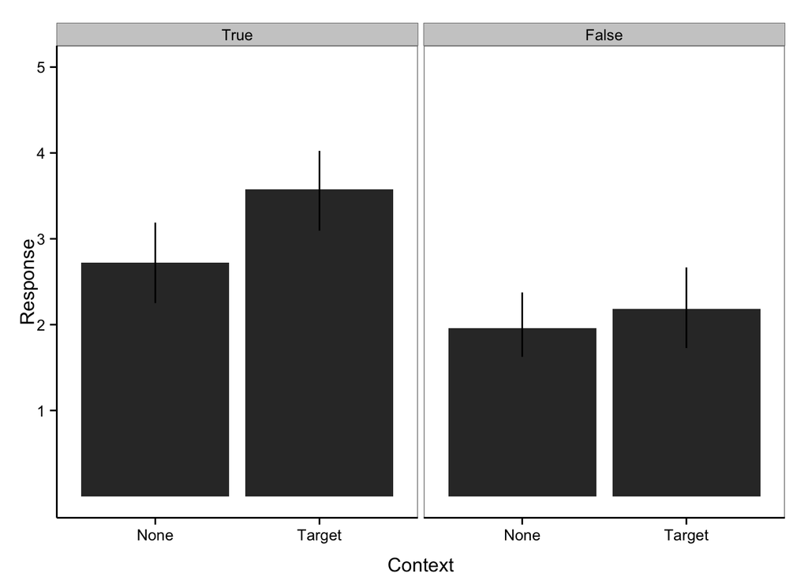

```r
qplot(data = subset(ms, sent.type == "Negative"),
      x = condition, y = m, facets = ~ truth,
      stat = "identity", position = "dodge", geom = "bar") +
  geom_errorbar(aes(ymin = cil, ymax = cih),
                position = position_dodge(.9), width = 0) +
  scale_fill_grey("") +
  xlab("Context") + ylab("Response") +
  scale_y_continuous(limits = c(0, 5), breaks = seq(1,5,1)) +
  plot.style
```

Histogram of trial ratings:

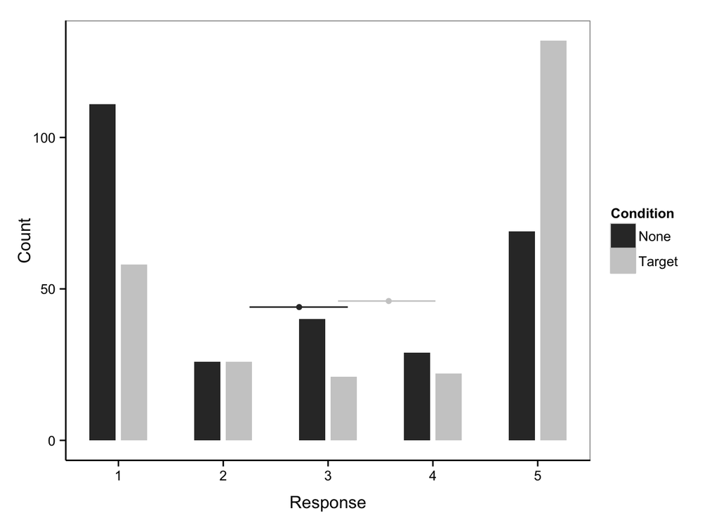

```r
truenegs <- filter(ms, truth == "True" & sent.type ==  "Negative")

#make df for histogram (for formatting reasons)
hist_data <- d.exp3 %>%
  filter(truth == "True" & sent.type == "Negative") %>%
  group_by(condition, resp) %>%
  summarise(count = n())

qplot(data = hist_data, y = count, x = resp,
      fill = condition, width = .5,
      geom = "bar", position = position_dodge(.6), stat = "identity") +
  geom_point(data = truenegs, aes(x = m, y = c(44, 46), color = condition)) +
  geom_segment(data = truenegs, aes(x = cil, xend = cih, y = c(44, 46), yend = c(44, 46), color = condition)) +
  scale_fill_grey("Condition") + scale_color_grey("Condition") +
  xlab("Response") + ylab("Count") +
  plot.style
```

### Plot data, broken down by age

Mean responses to negative sentences:

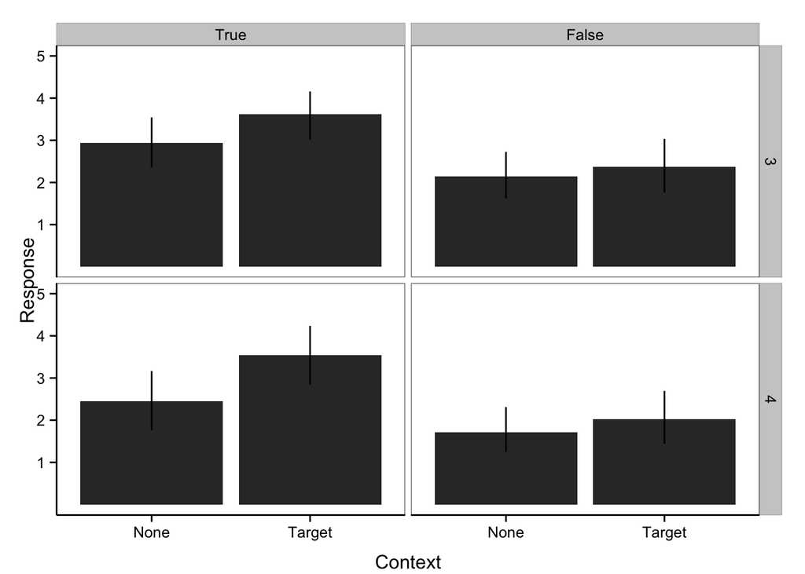

```r
ms <- d.exp3 %>%
  group_by(subid, agegroup, condition, sent.type, truth) %>%
  summarise(subm = mean(resp)) %>%
  group_by(condition, agegroup, sent.type, truth) %>%
  summarise(m = mean(subm),
            cih = ci.high(subm),
            cil = ci.low(subm))
ms$truth <- factor(ms$truth, levels=c("True","False"))

qplot(data = subset(ms, sent.type == "Negative"),
      x = condition, y = m, facets = agegroup~truth,
      stat = "identity", position = "dodge", geom = "bar") +
  geom_errorbar(aes(ymin = cil, ymax = cih),
                position = position_dodge(.9), width = 0) +
  scale_fill_grey("") +
  xlab("Context") + ylab("Response") +
  scale_y_continuous(limits = c(0, 5), breaks = seq(1,5,1)) +
  plot.style
```

Histogram of responses

Three-year-olds:

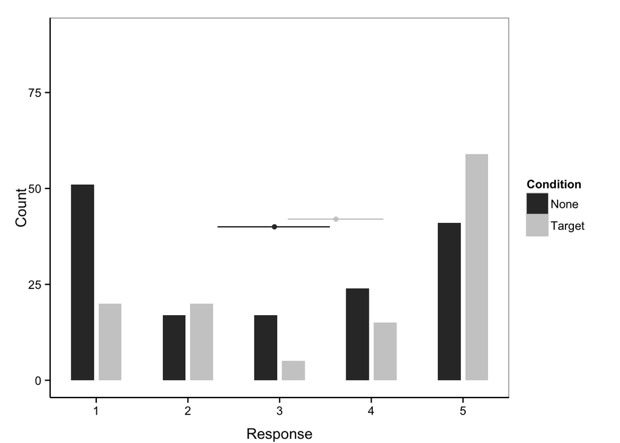

```r
ms <- d.exp3 %>%
  group_by(subid, agegroup, condition, sent.type, truth) %>%
  summarise(subm = mean(resp)) %>%
  group_by(condition, agegroup, sent.type, truth) %>%
  summarise(m = mean(subm),
            cih = ci.high(subm),
            cil = ci.low(subm))

trueneg_3s <- filter(ms, truth == "True" & sent.type ==  "Negative" & agegroup ==  "3")

hist_data_3s <- d.exp3 %>%
  filter(truth == "True" & sent.type == "Negative" & agegroup == "3") %>%
  group_by(condition, resp) %>%
  summarise(count = n())

qplot(data = hist_data_3s, y = count, x = resp,
      fill = condition, width = .5,
      geom = "bar", position = position_dodge(.6), stat = "identity") +
  geom_point(data = trueneg_3s, aes(x = m, y = c(40, 42), color = condition)) +
  geom_segment(data = trueneg_3s, aes(x = cil, xend = cih, y = c(40, 42), yend = c(40, 42), color = condition)) +
  scale_fill_grey("Condition") + scale_color_grey("Condition") +
  xlab("Response") + ylab("Count") +
  ylim(c(0, 90)) +
  plot.style
```

Four-year-olds:

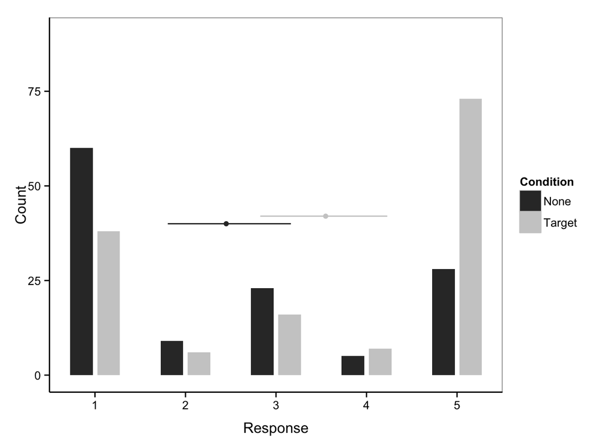

```r
trueneg_4s <- filter(ms, truth == "True" & sent.type ==  "Negative" & agegroup ==  "4")

hist_data_4s <- d.exp3 %>%
  filter(truth == "True" & sent.type == "Negative" & agegroup == "4") %>%
  group_by(condition, resp) %>%
  summarise(count = n())

qplot(data = hist_data_4s, y = count, x = resp,
      fill = condition, width = .5,
      geom = "bar", position = position_dodge(.6), stat = "identity") +
  geom_point(data = trueneg_4s, aes(x = m, y = c(40, 42), color = condition)) +
  geom_segment(data = trueneg_4s, aes(x = cil, xend = cih, y = c(40, 42), yend = c(40, 42), color = condition)) +
  scale_fill_grey("Condition") + scale_color_grey("Condition") +
  xlab("Response") + ylab("Count") +
  ylim(c(0, 90)) +
  plot.style
```

### Statistical models

Basic continuous models:

```r
model.noage <- lmer(resp ~ condition * truth  + (1|subid)
                    + (1|item),
                    data = filter(d.exp3, sent.type ==  "Negative"))
summary(model.noage)
```

```
## Linear mixed model fit by REML ['lmerMod']
## Formula: resp ~ condition * truth + (1 | subid) + (1 | item)
##    Data: filter(d.exp3, sent.type == "Negative")
##
## REML criterion at convergence: 2323.1
##
## Scaled residuals:
##     Min      1Q  Median      3Q     Max
## -2.4320 -0.5564 -0.0328  0.6729  3.3082
##
## Random effects:
##  Groups   Name        Variance Std.Dev.
##  subid    (Intercept) 1.134    1.065
##  item     (Intercept) 0.000    0.000
##  Residual             1.530    1.237
## Number of obs: 667, groups:  subid, 69; item, 16
##
## Fixed effects:
##                           Estimate Std. Error t value
## (Intercept)                 1.9832     0.2319   8.552
## conditionTarget             0.2463     0.3349   0.735
## truthTrue                   0.7415     0.1668   4.445
## conditionTarget:truthTrue   0.5959     0.2401   2.482
##
## Correlation of Fixed Effects:
##             (Intr) cndtnT trthTr
## conditnTrgt -0.693
## truthTrue   -0.574  0.398
## cndtnTrgt:T  0.399 -0.574 -0.695
```

```r
model.age <- lmer(resp ~ condition * agegroup * truth  + (1|subid)
                  + (1|item),
                  data = filter(d.exp3, sent.type ==  "Negative"))
summary(model.age)
```

```
## Linear mixed model fit by REML ['lmerMod']
## Formula: resp ~ condition * agegroup * truth + (1 | subid) + (1 | item)
##    Data: filter(d.exp3, sent.type == "Negative")
##
## REML criterion at convergence: 2321.6
##
## Scaled residuals:
##     Min      1Q  Median      3Q     Max
## -2.4416 -0.5323 -0.0247  0.6574  3.3832
##
## Random effects:
##  Groups   Name        Variance Std.Dev.
##  subid    (Intercept) 1.140    1.068
##  item     (Intercept) 0.000    0.000
##  Residual             1.533    1.238
## Number of obs: 667, groups:  subid, 69; item, 16
##
## Fixed effects:
##                                     Estimate Std. Error t value
## (Intercept)                          2.18347    0.31237   6.990
## conditionTarget                      0.22774    0.47603   0.478
## agegroup4                           -0.45023    0.46741  -0.963
## truthTrue                            0.76331    0.22557   3.384
## conditionTarget:agegroup4            0.11781    0.67440   0.175
## conditionTarget:truthTrue            0.43830    0.34168   1.283
## agegroup4:truthTrue                 -0.04702    0.33560  -0.140
## conditionTarget:agegroup4:truthTrue  0.29541    0.48296   0.612
##
## Correlation of Fixed Effects:
##             (Intr) cndtnT aggrp4 trthTr cndT:4 cndT:T agg4:T
## conditnTrgt -0.656
## agegroup4   -0.668  0.439
## truthTrue   -0.574  0.377  0.384
## cndtnTrgt:4  0.463 -0.706 -0.693 -0.266
## cndtnTrgt:T  0.379 -0.575 -0.253 -0.660  0.406
## aggrp4:trtT  0.386 -0.253 -0.574 -0.672  0.398  0.444
## cndtnTr:4:T -0.268  0.407  0.399  0.467 -0.574 -0.707 -0.695
```

```r
anova(model.age, model.noage)
```

```
## refitting model(s) with ML (instead of REML)
```

```
## Data: filter(d.exp3, sent.type == "Negative")
## Models:
## model.noage: resp ~ condition * truth + (1 | subid) + (1 | item)
## model.age: resp ~ condition * agegroup * truth + (1 | subid) + (1 | item)
##             Df    AIC    BIC  logLik deviance  Chisq Chi Df Pr(>Chisq)
## model.noage  7 2330.8 2362.3 -1158.4   2316.8
## model.age   11 2336.4 2386.0 -1157.2   2314.4 2.3504      4     0.6716
```

T-tests by age group:

```r
#Three-year-olds
threes <- filter(d.exp3, agegroup ==  "3")
threes_subs <- aggregate(resp ~ subid + condition, threes, mean)
t.test(resp ~ condition, threes_subs)
```

```
##
##  Welch Two Sample t-test
##
## data:  resp by condition
## t = -1.1626, df = 30.945, p-value = 0.2539
## alternative hypothesis: true difference in means is not equal to 0
## 95 percent confidence interval:
##  -0.8332835  0.2282204
## sample estimates:
##   mean in group None mean in group Target
##             3.152014             3.454545
```

```r
#Four-year-olds
fours <- filter(d.exp3, agegroup ==  "4")
fours_subs <- aggregate(resp ~ subid + condition, fours, mean)
t.test(resp ~ condition, fours_subs)
```

```
##
##  Welch Two Sample t-test
##
## data:  resp by condition
## t = -2.0693, df = 30.749, p-value = 0.04701
## alternative hypothesis: true difference in means is not equal to 0
## 95 percent confidence interval:
##  -1.129489914 -0.008010086
## sample estimates:
##   mean in group None mean in group Target
##              2.80625              3.37500
```